# Report 2 - Visualizing Kriging Variance

James Otto

6/22/2021

Again, we begin by simulating from a Gaussian process:

```r
library("tidyverse"); theme_set(theme_bw())
library("patchwork")

set.seed(1)

dom <- expand.grid(1:100, 1:100) %>%
  tibble() %>%
  rename(x = Var1, y = Var2) %>%
  slice_sample(n = 200)

data <- geoR::grf(grid = dom, cov.model = "exp", cov.pars = c(5, 30), nugget = 1)$data %>%
  {tibble(z = .)}

df <- bind_cols(dom, data)
```

Below is a visualization of the simulated data:

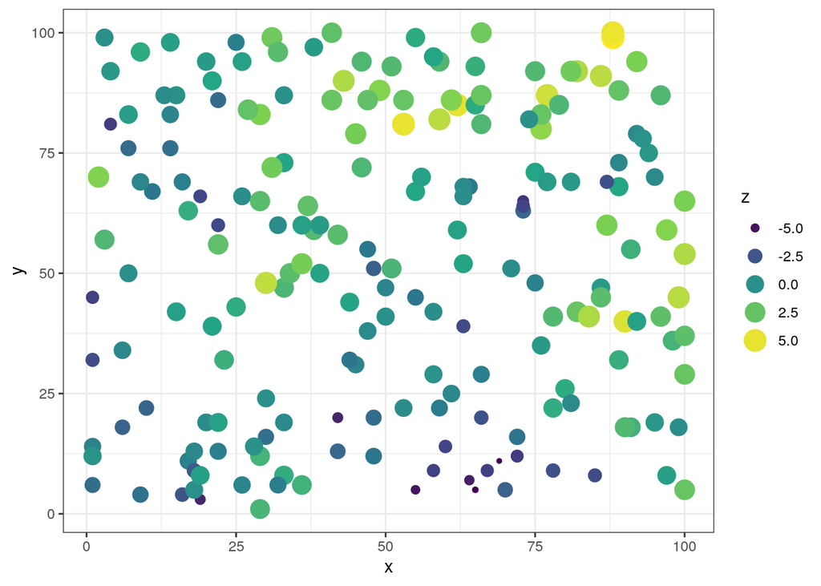

```r
ggplot(df, aes(x, y, color = z, size = z)) +
  geom_point() +
  scale_color_viridis_c() +
  guides(color = guide_legend(), size = guide_legend())
```

Loading the functions for extending ggplot2:

```r
source(here::here("ggplot_work/Spatial_Modeling/R/geom-krige.R"))
source(here::here("ggplot_work/Spatial_Modeling/R/stat-krige.R"))
source(here::here("ggplot_work/Spatial_Modeling/R/geom-krige-contour.R"))
source(here::here("ggplot_work/Spatial_Modeling/R/stat-krige-contour.R"))
```

Below, we have plotted the resulting kriging surface in heatmap form:

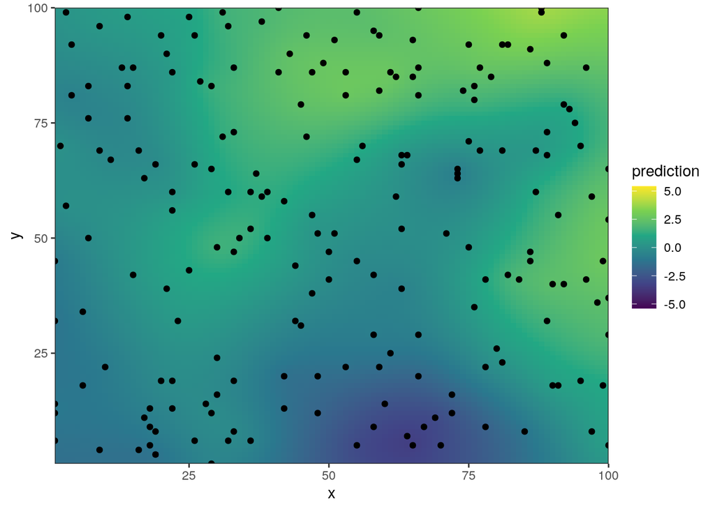

```r
p_krige_heatmap <- ggplot(df, aes(x, y, z = z)) +
  geom_krige(inits = c(6, 40), model = "exp") +
  geom_point() +
  scale_fill_viridis_c() +
  coord_cartesian(xlim = c(1, 100), ylim = c(1, 100), expand = FALSE)

p_krige_heatmap
```

And below, we have plotted a heatmap of the kriging variance. Unsurprisingly, we see that it is minimized at the locations corresponding to the observed values. Notice, the variance is available in the aesthetic mapping via the `after_stat` function (or `..var..`).

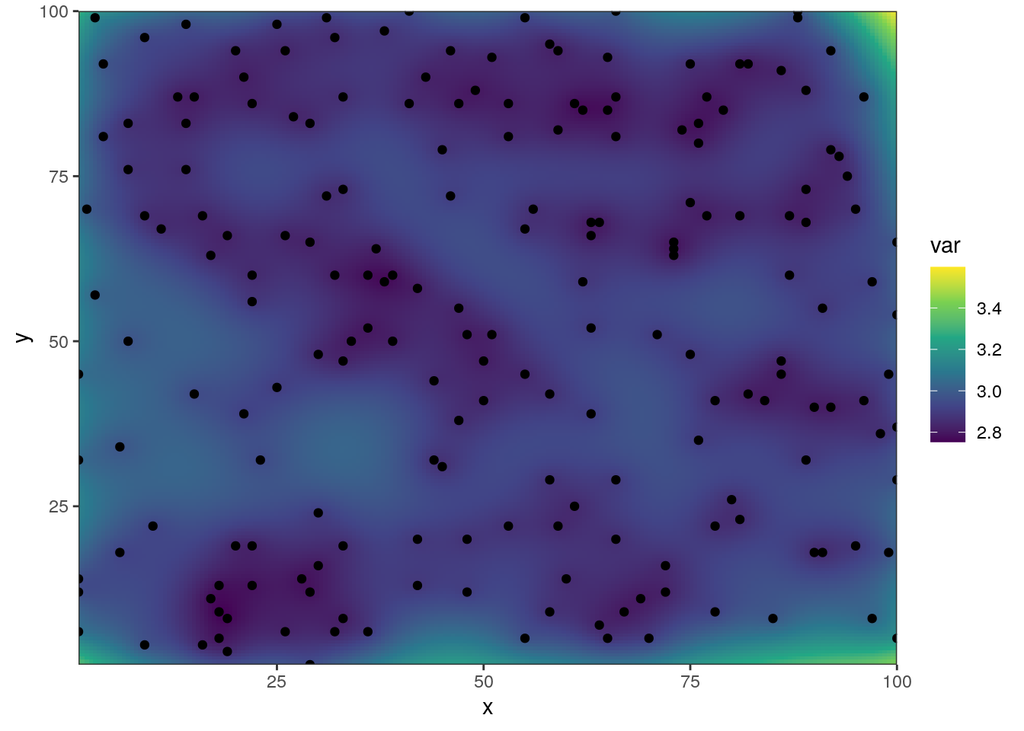

```r
p_var_heatmap <- ggplot(df) +
  geom_krige(aes(x, y, z = z, fill = after_stat(var)), inits = c(6, 40), model = "exp", nx = 200, ny = 200) +
  geom_point(aes(x, y)) +
  scale_fill_viridis_c() +
  coord_cartesian(xlim = c(1, 100), ylim = c(1, 100), expand = FALSE)

p_var_heatmap
```

Looking at these two plots side-by-side, we can get a sort of picture of the relationship between the kriging predictions and variance. However, this is difficult – there must be a better way to plot the kriging predictions alongside their variance.

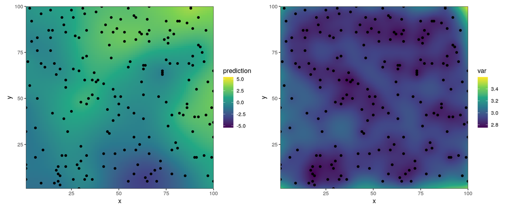

```r
p_krige_heatmap | p_var_heatmap
```

Interestingly, we had to change the resolution above for the kriging variance plot. When we approximate the surface with a $100 \times 100$ grid, it “syncs up” with the grid the data was simulated from. This results in some of the pixels being assigned a variance of 0, ruining the scale of the plot as shown below:

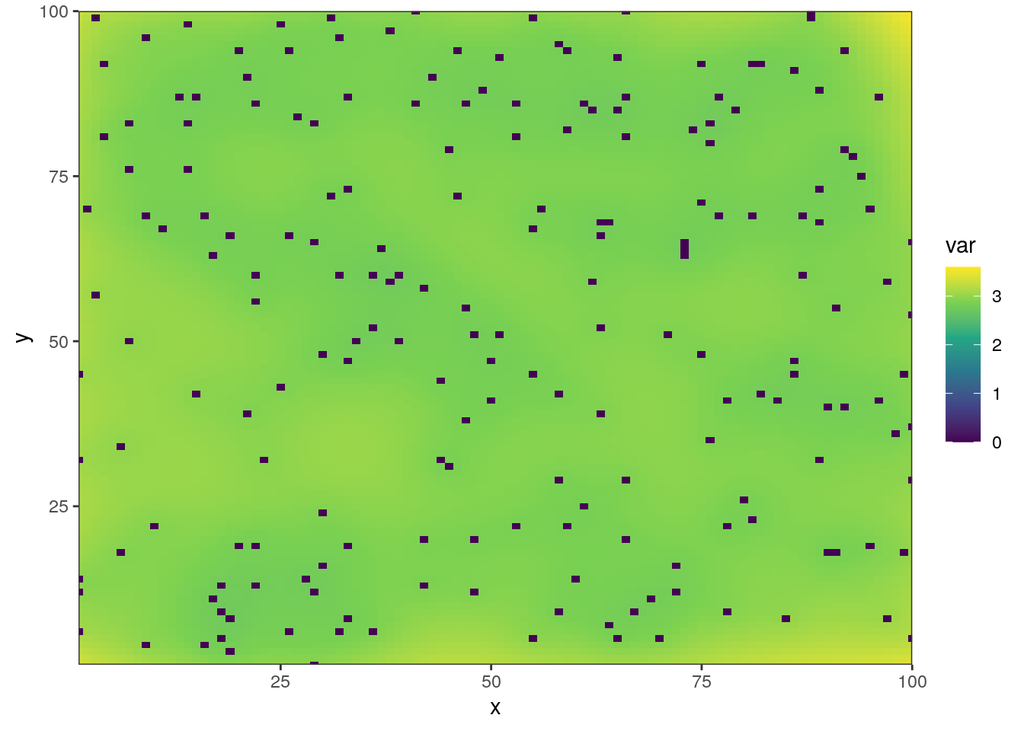

```r
ggplot(df) +
  geom_krige(aes(x, y, z = z, fill = after_stat(var)), inits = c(6, 40), model = "exp") +
  scale_fill_viridis_c() +
  coord_cartesian(xlim = c(1, 100), ylim = c(1, 100), expand = FALSE)
```

We can create similar plots with filled contours. While these are better (the variance plot better indicates regions of precision) they still seem to be suboptimal.

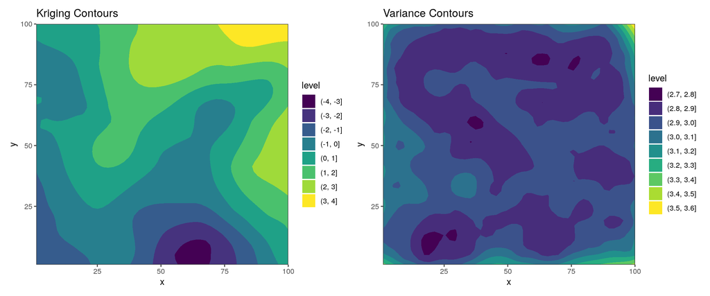

```r
p_contours <- ggplot(df, aes(x, y, z = z)) +
  geom_krige_contour_filled(inits = c(6, 40), model = "exp", nx = 50, ny = 50) +
  scale_fill_viridis_d() +
  coord_cartesian(xlim = c(1, 100), ylim = c(1, 100), expand = FALSE)

p_contours_var <- ggplot(df, aes(x, y, z = z)) +
  geom_krige_contour_filled(inits = c(6, 40), model = "exp", nx = 50, ny = 50, var = TRUE) +
  scale_fill_viridis_d() +
  coord_cartesian(xlim = c(1, 100), ylim = c(1, 100), expand = FALSE)

(p_contours + ggtitle("Kriging Contours")) |
(p_contours_var + ggtitle("Variance Contours"))
```

We can also combine the use of contours and filled contours:

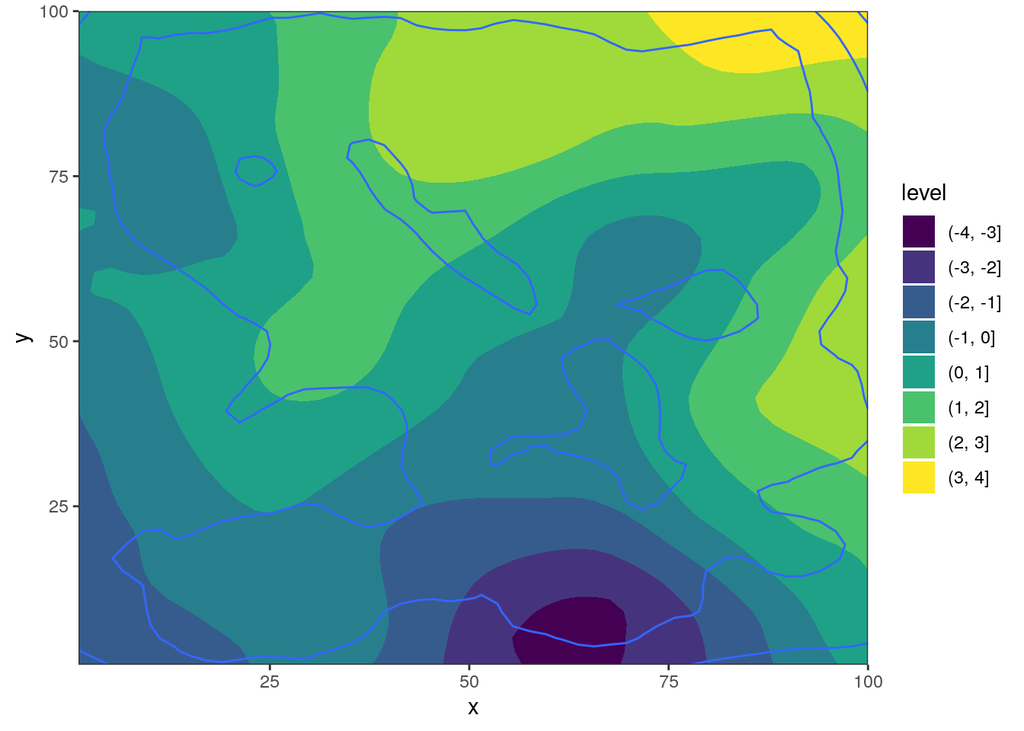

```r
ggplot(df, aes(x, y, z = z)) +
  geom_krige_contour_filled(inits = c(6, 40), model = "exp", nx = 50, ny = 50) +
  geom_krige_contour(inits = c(6, 40), model = "exp", nx = 50, ny = 50, var = TRUE, bins = 4) +
  scale_fill_viridis_d() +
  coord_cartesian(xlim = c(1, 100), ylim = c(1, 100), expand = FALSE)
```

We are interested in plots similar to above with labeled contours – this is something to look into.

Note that this in these examples, we have to specify `var = TRUE` as an argument for the geom. While I do not like the inconsitency between `geom_krige` and `geom_krige_contour` this seems to be necessary. It is simple enough to provide the computed kriging variance for each pixel in `stat_krige` and allow for its use in the aesthetic mapping. However, it is not so easy for the contours. The data is transformed considerably in the process of evaluating `stat_krige_contour`, in order to create contours for the variance ggplot has to “know” before getting to the `compute_group` stage.

It may be good to allow for a “helper” argument, `var = TRUE`, in `geom_krige` for consistency.

Below, we have associated the alpha level of each pixel with its kriging variance:

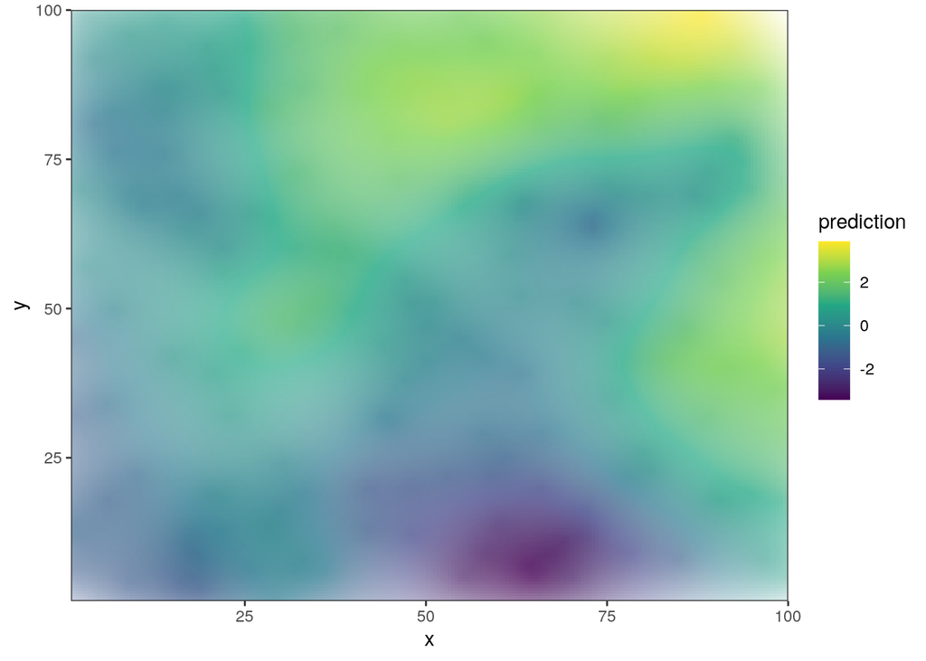

```r
ggplot(df, aes(x, y, z = z)) +
  geom_krige(aes(alpha = after_stat(var)), inits = c(6, 40), model = "exp", nx = 200, ny = 200) +
  coord_cartesian(xlim = c(1, 100), ylim = c(1, 100), expand = FALSE) +
  scale_fill_viridis_c() +
  scale_alpha_continuous(range = c(.9, 0)) + # Have to flip scale
  guides(alpha = "none") +
  theme(panel.grid = element_blank()) # Have to hide gridlines or they "peak out"
```

Below, we have added a “cloudy effect” to indicate regions with lower levels of precision. (We are unable to adjust alpha according to variance for filled contour plots).

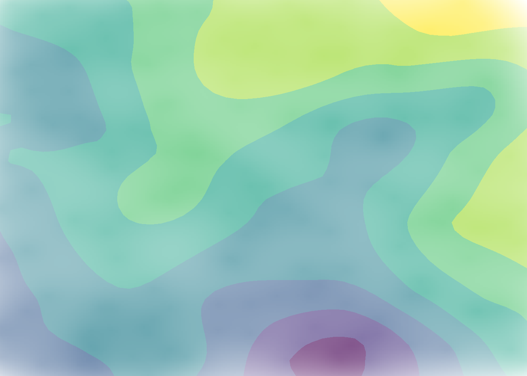

```r
p_var_cloudy <- ggplot(df, aes(x, y, z = z)) +
  geom_krige(aes(alpha = after_stat(var)), inits = c(6, 40), model = "exp", nx = 250, ny = 250, fill = "white") +
  coord_cartesian(xlim = c(1, 100), ylim = c(1, 100), expand = FALSE) +
  scale_alpha_continuous(range = c(.3, 1))

library("grid")
grid.newpage()
pushViewport(viewport(layout = grid.layout(1, 1, widths = unit(1 , "npc"))))
print(p_contours +
        theme_void() +
        theme(legend.position = "none"), vp = viewport(layout.pos.row = 1, layout.pos.col = 1))
print(p_var_cloudy +
        theme_void() +
        theme(legend.position = "none"), vp = viewport(layout.pos.row = 1, layout.pos.col = 1))
```

Note, ggplot does not like having multiple fill scales in a single plot. The above workaround is odd, and is more a proof of concept.